# DP3 performance analysis and optimization

Parallelism, memory accesses and vectorization

Hamza Chouh, EPFL

## DP3 in the SKA Science Data Processor

- DP3: LOFAR pipeline software (ASTRON): averaging, flagging, calibration, prediction
- Used for the preprocessing / self-calibration engine of the SKA Science Data Processor
- Self-calibration alternates **predict** (simulate a model sky) and **solve** (fit corrections against it)

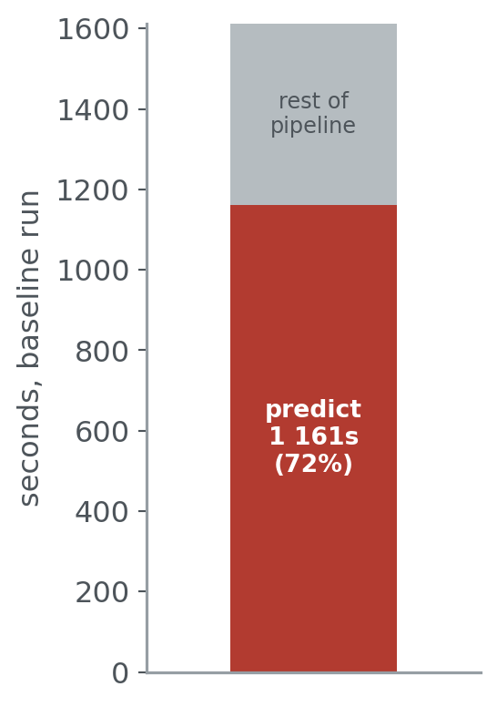

## The predict step

- Simulates model visibilities for every baseline × channel × correlation, from a sky model and a telescope model
- Per source: simulate its contribution, accumulate into a per-patch buffer
- Per patch: compute the beam response, apply it to that patch’s buffer
- Mostly DP3 internal implementation; calls EveryBeam for the beam response

Test configuration used for benchmarking in this talk

| quantity | value |
| --- | --- |
| stations | 68 |
| baselines | 2 278 |
| channels | 416 |
| sky components | 25 085 |
| polarization | unpolarized (Stokes I only) |
| patches | 14 365 |
| timesteps | 100 |
| machine | 72 cores (2x Intel Xeon Platinum 8360Y) |

## Original work distribution

**Structure:**

- Sources statically split into equal-count slices, one per thread
- Each thread simulates its sources and computes beam responses independently into a private accumulator

**Potential issues:**

- Can result in a workload discrepancy
- Beam computations are duplicated when shared among multiple threads

| metric | value |
| --- | --- |
| predict | 1 161 s |
| wall | 1 612 s |
| user CPU | 66 623 s |
| mean parallelism | 41.3× of 72 (57%) |

## Performance measurements

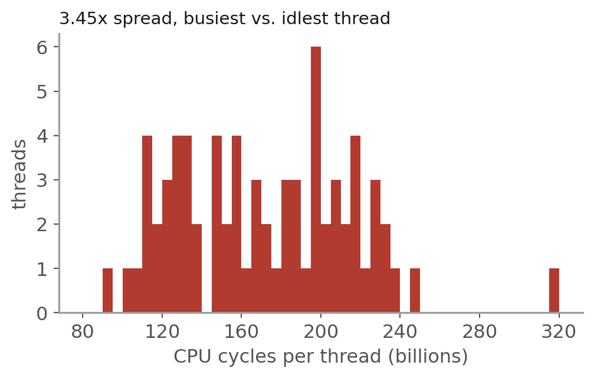

- **32.0%** effective CPU utilization — 23.0 of 72 cores (VTune, spin and overhead discounted)

- **3.45x** cycle-count spread, busiest vs. idlest core

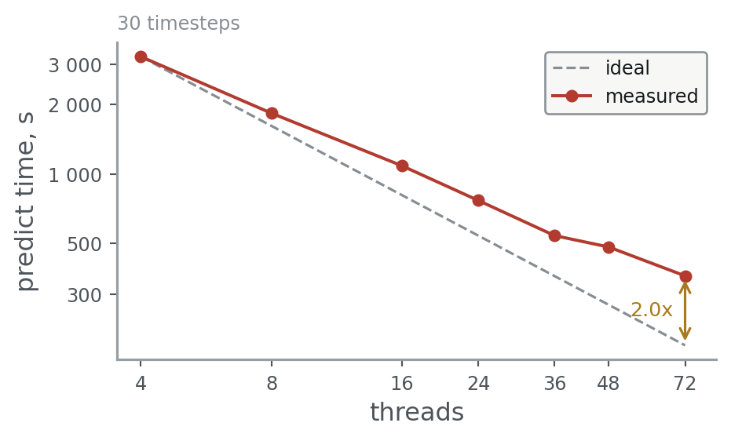

- 4→72 threads: **9.0x** against an ideal 18x — 50% scaling efficiency

## Per-thread load

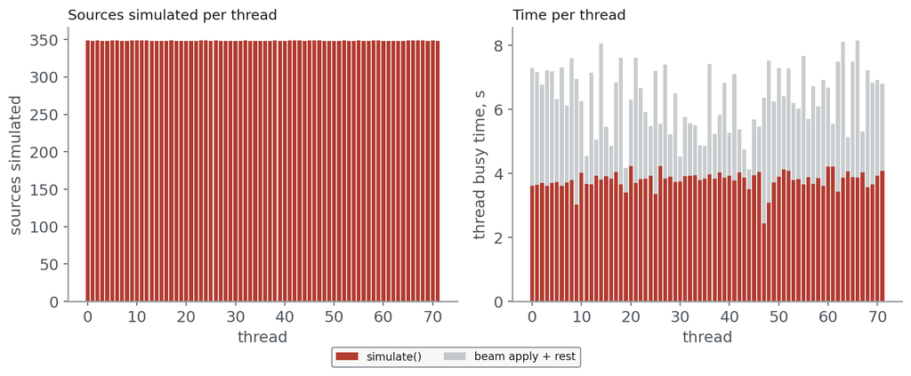

- Flat item count: 348–349 sources on every thread, yet thread time spreads **2.0x**
- `simulate()` itself only spreads 1.7x — 93% of components are Gaussian, so an equal-count split gives every thread much the same mix
- The spread is in the rest: the beam-apply remainder varies **7.2x** across threads and is 40% of thread busy time
- Equal *source* counts are not equal *patch* counts — and the beam fires per patch

## Dynamic dispatch via Intel Thread Building Blocks (TBB) library

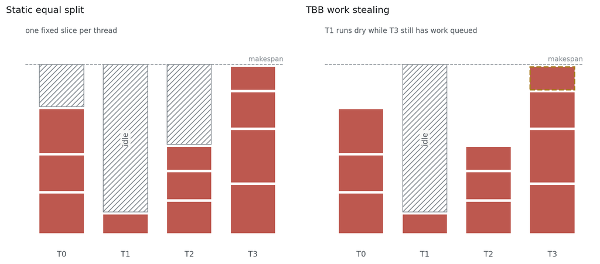

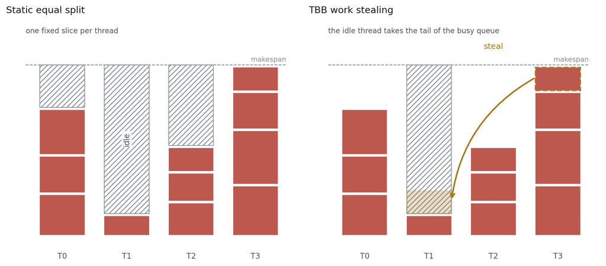

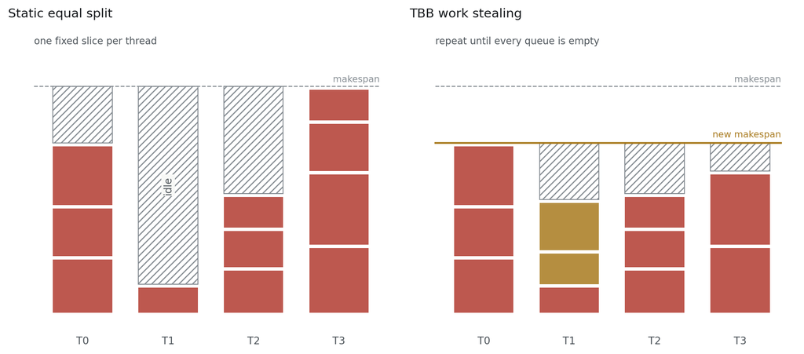

- Same per-source granularity as the static split, dispatched dynamically through `tbb::parallel_for` instead of a fixed slice per thread
- Work-stealing scheduler: idle threads pick up remaining sources instead of sitting still
- Low overhead scheduler + minimal code to maintain

## TBB attempt: results

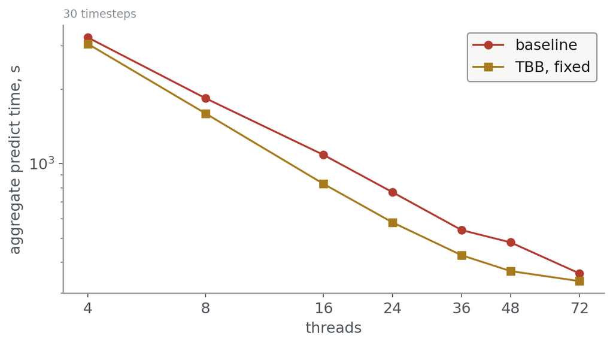

**6–24% faster** than the static baseline at every measured thread count: 24% at 24 threads, but 7% at 72. Still far short of what the profiling budget suggested was available.

## Per-thread load, TBB

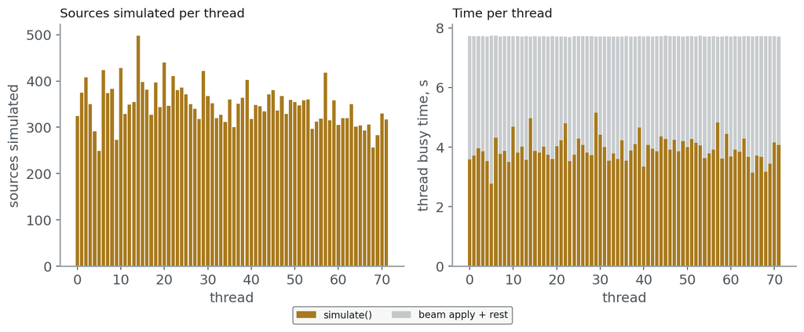

- Work stealing redistributes work ☭: between 249 and 498 items per thread
- Better per-thread time balance
- Only 5% of the makespan saved at 72 threads: total work grew 22% (456 → 556 thread-seconds)
- 89 of those 100 extra thread-seconds are beam applies (183 → 272, +49%): the same patch is re-applied in every range that touches it

| metric | static split | TBB stealing |
| --- | --- | --- |
| thread utilization | 77.4% | 99.6% |
| time spread | 64.2% | 0.6% |
| idle, per timestep | 1.88s | 0.03s |

Over a thread’s whole work, per timestep, averaged over 28 timesteps.

## Removing the redundant beam applies

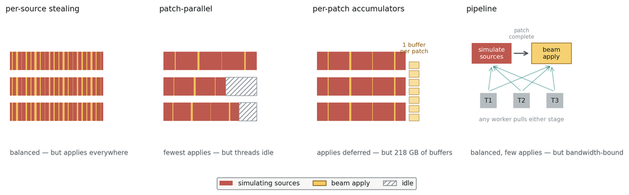

- Structural redundancy: a patch split across a range boundary is applied once in **each** range — applies ≈ patches + ranges, so the finer the stealing, the more applies
- Four variants tried, verdicts under each panel

  ==> General conclusion: tradeoff between parallelism efficiency and memory overhead

## Memory traffic

- Next step was to look at memory reads/writes and how to optimize them

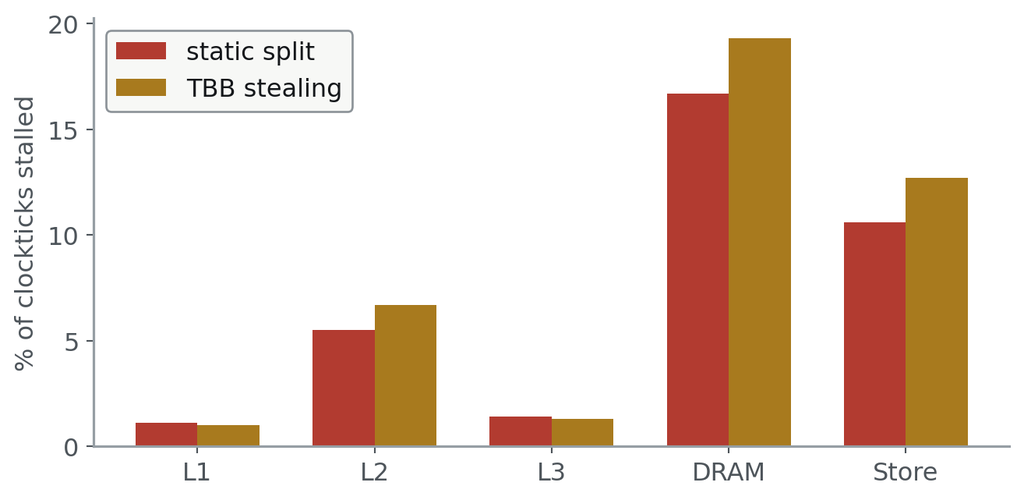

| metric | static | TBB |
| --- | --- | --- |
| Memory Bound | 77% | 76% |
| L3 Bound | 1.4% | 1.3% |
| DRAM Bound | 16.7% | 19.3% |
| Load ops | 1.9T | 2.1T |
| LLC misses | 4.8B | 5.1B |

Work stealing moves **+6% LLC misses** in our test case.

## Tile by channel and source

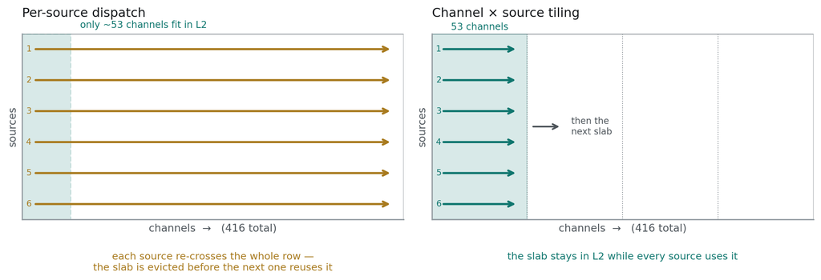

- Each thread works a channel slab × source block tile sized to stay inside L2, instead of every source sweeping the full channel range
- Current implementation only works on unpolarized sky models
- **Hypothesis**: expected to cut cache misses and reduce pressure on DDR

## Impact of the new layout

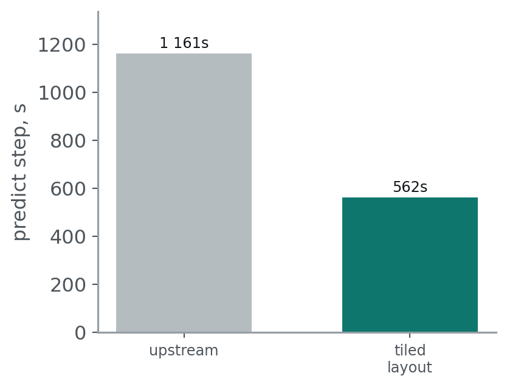

- 1 161s → 562s predict time, **2.07x**
- Beam applications are done on-the-fly in the Stokes-I path, so the per-patch buffer round-trip disappears: 183s of thread time → 0.5s
- Hypothesis confirmed — the tile really does keep a thread’s working set in cache:

|  | original | tiled |  |
| --- | --- | --- | --- |
| memory bound | 77% | **13%** | 6.0× |
| DRAM bound | 17% | **3%** | 5.8× |
| store bound | 10.6% | **0.9%** | 11.8× |
| LLC misses | 4.8 B | **0.33 B** | 14.6× |

Memory traffic analysis of the simulation phase of the prediction step.

## Vectorizing the inner loops

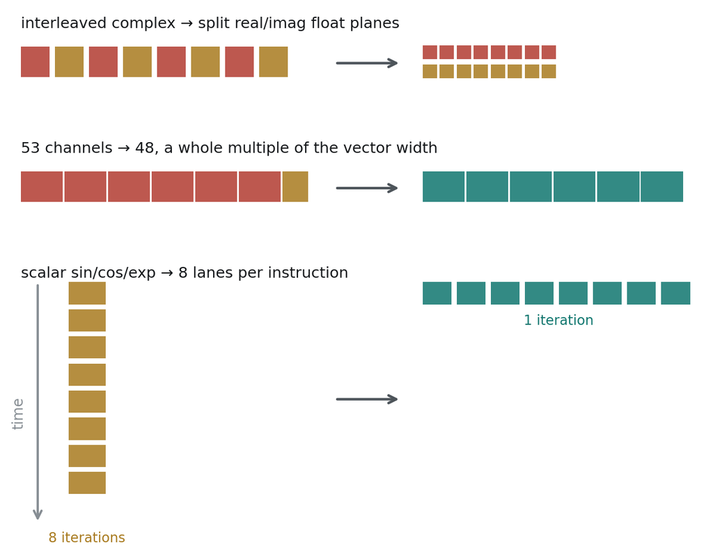

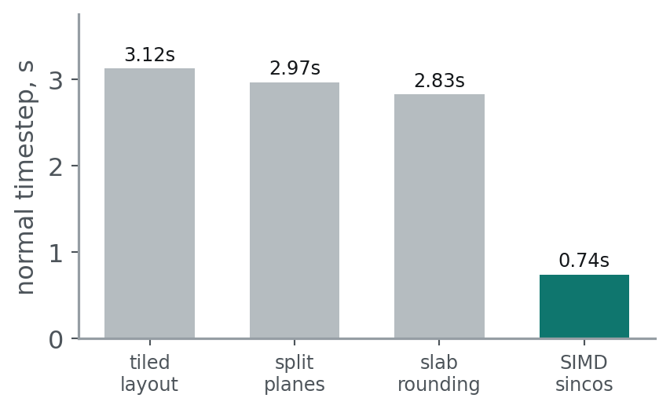

- Structure of arrays pattern for processing, then written into array of structures
- Slab rounded to a multiple of an SIMD lane to avoid scalar epilogues
- `xsimd::sincos` in `phases()` and `xsimd::exp` in the Gaussian envelope
- Combined performance gain: 3.12s → 0.74s per normal timestep, **4.2x** (1.67x on the whole predict step)

## Overall effect

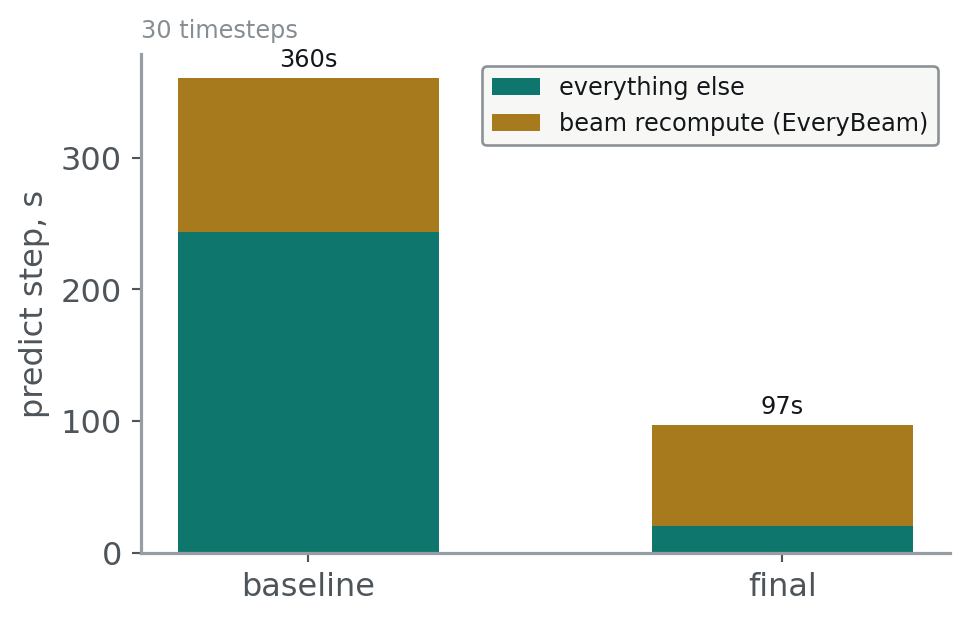

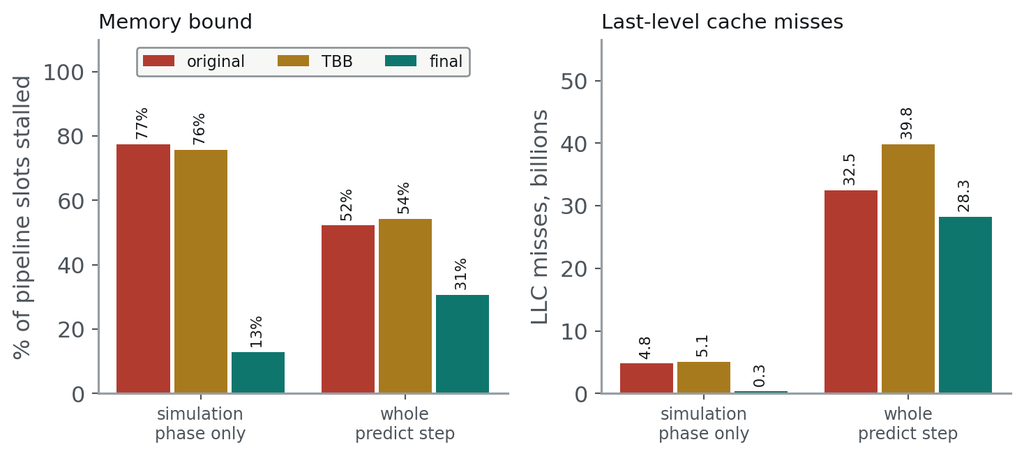

- The work was on the simulation step only, which was dominant.
- Beam compute is now **79%** of the predict step.
- On the simulation phase, memory bound 77% → **13%** and **14.6x** fewer LLC misses
- Over the whole predict step both shrink less: the untouched beam dominates what is left

## Per-thread load, final version

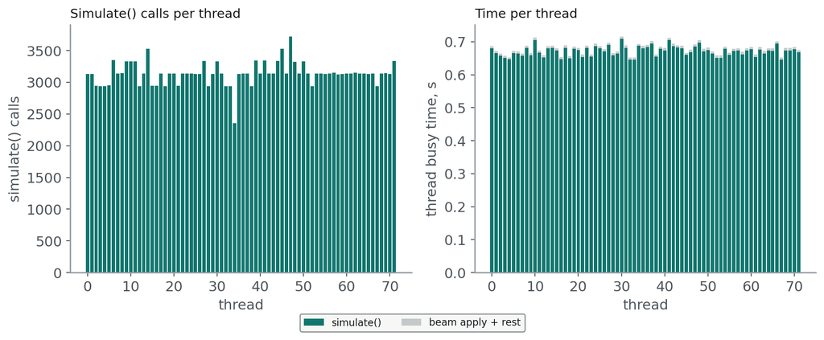

- Beam application is now contained in `simulate()`
- Residual spread is a granularity floor: going finer leads to worse performance

## Final results

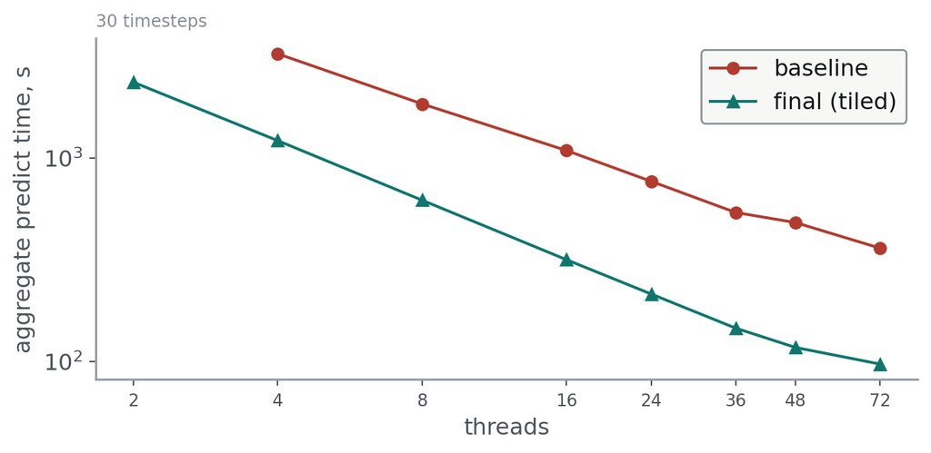

- **3.4x** faster predict step, upstream → current (1 161s → 337s over the full 100 timesteps; the sweep above is the 30-timestep one)

## Full dataset, end to end

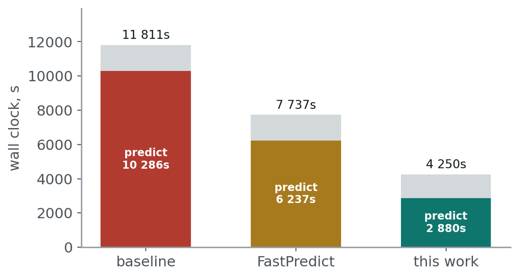

- The production pipeline over the whole 900-timestep set, one node, one binary: **11 811s → 4 250s** wall clock, 7 561s saved per run
- Predict step **3.57x**, and 2.17x against FastPredict

## Conclusion / discussion

- Correctness: unit tests + results validated on a realistic test case
- Good performance gains through a loop reordering
- Takeaway:
  - a better scheduler alone had a ceiling close to the baseline
  - it balanced the threads much better
  - but paid for it in both compute and memory accesses from redundant per-patch work
  - the real gain came from reordering memory access
- Perspective:
  - polarized sky models. The tiled path needs Stokes I today; applying the Jones matrix per patch **per channel slab** keeps the tile in L2 and saves memory traffic
  - GPU implementation
  - applying FastPredict improvements (look into trigonometry lookup tables, source type batching, some possible precompute)